# Project: Investigate a Dataset - [TMDB Movies Data]

- Introduction
- Data Wrangling
- Exploratory Data Analysis
- Conclusions

## Introduction

### Dataset Description

It contains data like Popularity, Genre, Runtime, Revenue, and Release Date for 10000 movies. Colunms in this dataset: 'id', 'imdb_id', 'popularity', 'budget', 'revenue', 'original_title', 'cast', 'homepage', 'director', 'tagline', 'keywords', 'overview', 'runtime', 'genres', 'production_companies', 'release_date', 'vote_count', 'vote_average', 'release_year', 'budget_adj', 'revenue_adj'

### Question(s) for Analysis

Q1) What are the properties assosiaded with each Gernre? Q2) Which production company made the most popular movies in each year? Q3) Who are the most popular directors Q4) What are the properties of popular Movies

```python
import pandas as pd
import numpy as np
import matplotlib.pyplot as plt
% matplotlib inline
```

```
UsageError: Line magic function `%` not found.
```

## Data Wrangling

### General Properties

```python
df = pd.read_csv('tmdb-movies.csv')
df.head()
```

|  | id | imdb_id | popularity | budget | revenue | original_title | cast | homepage | director | tagline | ... | overview | runtime | genres | production_companies | release_date | vote_count | vote_average | release_year | budget_adj | revenue_adj |
| --- | --- | --- | --- | --- | --- | --- | --- | --- | --- | --- | --- | --- | --- | --- | --- | --- | --- | --- | --- | --- | --- |
| 0 | 135397 | tt0369610 | 32.985763 | 150000000 | 1513528810 | Jurassic World | Chris Pratt\|Bryce Dallas Howard\|Irrfan Khan\|Vi... | http://www.jurassicworld.com/ | Colin Trevorrow | The park is open. | ... | Twenty-two years after the events of Jurassic ... | 124 | Action\|Adventure\|Science Fiction\|Thriller | Universal Studios\|Amblin Entertainment\|Legenda... | 6/9/15 | 5562 | 6.5 | 2015 | 1.379999e+08 | 1.392446e+09 |
| 1 | 76341 | tt1392190 | 28.419936 | 150000000 | 378436354 | Mad Max: Fury Road | Tom Hardy\|Charlize Theron\|Hugh Keays-Byrne\|Nic... | http://www.madmaxmovie.com/ | George Miller | What a Lovely Day. | ... | An apocalyptic story set in the furthest reach... | 120 | Action\|Adventure\|Science Fiction\|Thriller | Village Roadshow Pictures\|Kennedy Miller Produ... | 5/13/15 | 6185 | 7.1 | 2015 | 1.379999e+08 | 3.481613e+08 |
| 2 | 262500 | tt2908446 | 13.112507 | 110000000 | 295238201 | Insurgent | Shailene Woodley\|Theo James\|Kate Winslet\|Ansel... | http://www.thedivergentseries.movie/#insurgent | Robert Schwentke | One Choice Can Destroy You | ... | Beatrice Prior must confront her inner demons ... | 119 | Adventure\|Science Fiction\|Thriller | Summit Entertainment\|Mandeville Films\|Red Wago... | 3/18/15 | 2480 | 6.3 | 2015 | 1.012000e+08 | 2.716190e+08 |
| 3 | 140607 | tt2488496 | 11.173104 | 200000000 | 2068178225 | Star Wars: The Force Awakens | Harrison Ford\|Mark Hamill\|Carrie Fisher\|Adam D... | http://www.starwars.com/films/star-wars-episod... | J.J. Abrams | Every generation has a story. | ... | Thirty years after defeating the Galactic Empi... | 136 | Action\|Adventure\|Science Fiction\|Fantasy | Lucasfilm\|Truenorth Productions\|Bad Robot | 12/15/15 | 5292 | 7.5 | 2015 | 1.839999e+08 | 1.902723e+09 |
| 4 | 168259 | tt2820852 | 9.335014 | 190000000 | 1506249360 | Furious 7 | Vin Diesel\|Paul Walker\|Jason Statham\|Michelle ... | http://www.furious7.com/ | James Wan | Vengeance Hits Home | ... | Deckard Shaw seeks revenge against Dominic Tor... | 137 | Action\|Crime\|Thriller | Universal Pictures\|Original Film\|Media Rights ... | 4/1/15 | 2947 | 7.3 | 2015 | 1.747999e+08 | 1.385749e+09 |

5 rows × 21 columns

### Data Cleaning

Removing Duplicates

```python
df.drop_duplicates(inplace=True)
df.info()
```

```
<class 'pandas.core.frame.DataFrame'>
Int64Index: 10865 entries, 0 to 10865
Data columns (total 21 columns):
 #   Column                Non-Null Count  Dtype
---  ------                --------------  -----
 0   id                    10865 non-null  int64
 1   imdb_id               10855 non-null  object
 2   popularity            10865 non-null  float64
 3   budget                10865 non-null  int64
 4   revenue               10865 non-null  int64
 5   original_title        10865 non-null  object
 6   cast                  10789 non-null  object
 7   homepage              2936 non-null   object
 8   director              10821 non-null  object
 9   tagline               8041 non-null   object
 10  keywords              9372 non-null   object
 11  overview              10861 non-null  object
 12  runtime               10865 non-null  int64
 13  genres                10842 non-null  object
 14  production_companies  9835 non-null   object
 15  release_date          10865 non-null  object
 16  vote_count            10865 non-null  int64
 17  vote_average          10865 non-null  float64
 18  release_year          10865 non-null  int64
 19  budget_adj            10865 non-null  float64
 20  revenue_adj           10865 non-null  float64
dtypes: float64(4), int64(6), object(11)
memory usage: 1.8+ MB
```

## Exploratory Data Analysis

### Q1) What are the properties assosiaded with each Gernre?

splitting the genres in the genres column into separate rows and then removing the original rows.

```python
df_q1=df[df.genres.notna()]
df_q1=df_q1[df_q1.revenue.notna()]
df_q1.reset_index(drop=True, inplace=True)
to_add = []
to_remove = []
for x in range(df_q1['genres'].size):
    if "|" in df_q1['genres'][x]:
        genlst = df_q1['genres'][x].split("|")
        to_remove.append(x)
        row = df_q1.iloc[x, :].copy()
        for gen in genlst:
            temp = row.copy()
            temp['genres'] = gen
            to_add.append(temp.values)

df_q1.drop(to_remove, inplace=True)
to_add = pd.DataFrame(to_add, columns = df.columns)
df_q1 = df_q1.append(to_add)
```

getting the average Revenue and popularity and rating and creating a new score stat to rank each genre.

```python
ans = df_q1.groupby('genres').mean()['revenue'].reset_index()
pop = df_q1.groupby('genres').mean()['popularity'].reset_index()
rate = df_q1.groupby('genres').mean()['vote_average'].reset_index()
ans = ans.transpose()
ans = ans.append(pop['popularity'])
ans = ans.append(rate['vote_average'])
q1 = ans.transpose()
q1['score']=((q1['revenue']/100000000)+q1['popularity']+(q1['vote_average']/5))/3
q1
```

|  | genres | revenue | popularity | vote_average | score |
| --- | --- | --- | --- | --- | --- |
| 0 | Action | 72794732.002517 | 0.926274 | 5.787752 | 0.937257 |
| 1 | Adventure | 113137861.069341 | 1.154259 | 5.940585 | 1.157918 |
| 2 | Animation | 75256062.223176 | 0.852182 | 6.403147 | 0.961791 |
| 3 | Comedy | 37526242.072238 | 0.592607 | 5.905167 | 0.716301 |
| 4 | Crime | 42368661.645495 | 0.74493 | 6.124889 | 0.797865 |
| 5 | Documentary | 2041106.994231 | 0.181432 | 6.908462 | 0.527845 |
| 6 | Drama | 29232255.72584 | 0.591495 | 6.165546 | 0.705642 |
| 7 | Family | 72433176.37368 | 0.786668 | 5.997563 | 0.903504 |
| 8 | Fantasy | 96313657.081878 | 0.99284 | 5.863537 | 1.042895 |
| 9 | Foreign | 1520459.835106 | 0.191496 | 5.981383 | 0.467659 |
| 10 | History | 32011793.215569 | 0.575936 | 6.410479 | 0.72605 |
| 11 | Horror | 16822808.624313 | 0.465357 | 5.337447 | 0.567025 |
| 12 | Music | 28571768.691176 | 0.487321 | 6.480392 | 0.689706 |
| 13 | Mystery | 40217566.661728 | 0.690012 | 5.94679 | 0.760515 |
| 14 | Romance | 35691972.327103 | 0.592082 | 6.042874 | 0.719192 |
| 15 | Science Fiction | 70140558.034174 | 1.001548 | 5.665582 | 0.945357 |
| 16 | TV Movie | 251497.005988 | 0.270896 | 5.788024 | 0.477005 |
| 17 | Thriller | 41728417.54386 | 0.741563 | 5.750671 | 0.76966 |
| 18 | War | 47605183.3 | 0.727683 | 6.297778 | 0.821097 |
| 19 | Western | 28568709.284848 | 0.590615 | 6.08303 | 0.697636 |

Filtering the data and getting the genre with the highest total revenue in each year.

```python
temp = df_q1.groupby(['release_year', 'genres']).sum()['revenue'].unstack()
temp2 = temp.idxmax(axis=1)
ans = pd.DataFrame(temp2.values, index = temp2.index)
ans = ans.transpose()
ans
```

| release_year | 1960 | 1961 | 1962 | 1963 | 1964 | 1965 | 1966 | 1967 | 1968 | 1969 | ... | 2006 | 2007 | 2008 | 2009 | 2010 | 2011 | 2012 | 2013 | 2014 | 2015 |
| --- | --- | --- | --- | --- | --- | --- | --- | --- | --- | --- | --- | --- | --- | --- | --- | --- | --- | --- | --- | --- | --- |
| 0 | Drama | Adventure | Adventure | Thriller | Music | Drama | Drama | Adventure | Drama | Drama | ... | Comedy | Adventure | Action | Adventure | Adventure | Adventure | Adventure | Adventure | Action | Adventure |

1 rows × 56 columns

Representing The top earning genres of all time in a pie chart.

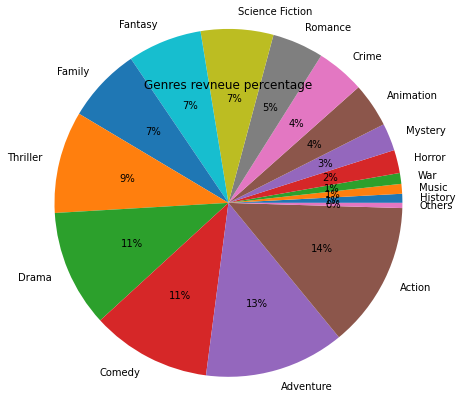

```python
ans = df_q1.groupby('genres').sum()['revenue'].sort_values()
ans['Others'] = ans['Foreign'] + ans['TV Movie'] + ans['Documentary'] + ans['Western']
ans.drop(['Foreign', 'TV Movie', 'Documentary', 'Western'], inplace = True)
ans
plt.pie(ans.values, labels = ans.index, radius = 2, autopct='%1.0f%%')
plt.title('Genres revneue percentage')
```

The most earning genres are Action, Adventure,and comedy

Filtering the data and getting the most popular genre in each year.

```python
temp = df_q1.groupby(['release_year', 'genres']).sum()['popularity'].unstack()
temp2 = temp.idxmax(axis=1)
ans = pd.DataFrame(temp2.values, index = temp2.index)
ans.transpose()
```

| release_year | 1960 | 1961 | 1962 | 1963 | 1964 | 1965 | 1966 | 1967 | 1968 | 1969 | ... | 2006 | 2007 | 2008 | 2009 | 2010 | 2011 | 2012 | 2013 | 2014 | 2015 |
| --- | --- | --- | --- | --- | --- | --- | --- | --- | --- | --- | --- | --- | --- | --- | --- | --- | --- | --- | --- | --- | --- |
| 0 | Drama | Drama | Drama | Thriller | Comedy | Drama | Drama | Drama | Drama | Drama | ... | Drama | Drama | Drama | Drama | Drama | Drama | Drama | Drama | Drama | Drama |

1 rows × 56 columns

Representing the data in a pie chart

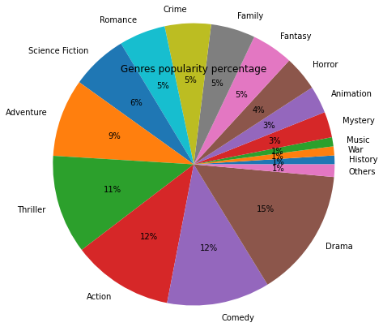

```python
ans = df_q1.groupby('genres').sum()['popularity'].sort_values()
ans['Others'] = ans['Foreign'] + ans['TV Movie'] + ans['Documentary'] + ans['Western']
ans.drop(['Foreign', 'TV Movie', 'Documentary', 'Western'], inplace = True)
ans
plt.pie(ans.values, labels = ans.index, radius = 2, autopct='%1.0f%%')
plt.title('Genres popularity percentage')
```

The most popular genres are Drama, Comedy,and Action

Filtering the data and getting the genre with the highest rating average in each year.

```python
temp = df_q1.groupby(['release_year', 'genres']).mean()['vote_average'].unstack()
temp2 = temp.idxmax(axis=1)
ans = pd.DataFrame(temp2.values, index = temp2.index)
ans.transpose()
```

| release_year | 1960 | 1961 | 1962 | 1963 | 1964 | 1965 | 1966 | 1967 | 1968 | 1969 | ... | 2006 | 2007 | 2008 | 2009 | 2010 | 2011 | 2012 | 2013 | 2014 | 2015 |
| --- | --- | --- | --- | --- | --- | --- | --- | --- | --- | --- | --- | --- | --- | --- | --- | --- | --- | --- | --- | --- | --- |
| 0 | Family | Mystery | Western | War | War | Animation | Documentary | War | Mystery | Crime | ... | Documentary | Documentary | Documentary | Documentary | War | Documentary | Music | Documentary | Documentary | Documentary |

1 rows × 56 columns

Representing the data in a bar chart

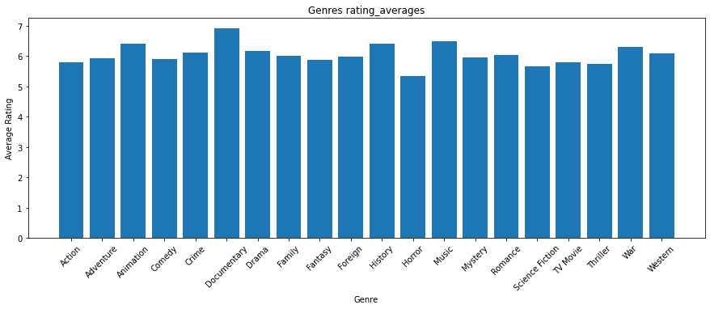

```python
# ans = df_q1.groupby('genres').sum()['vote_average'].sort_values()
ans = df_q1.groupby('genres').mean()['vote_average'].reset_index()
ans
plt.subplots(figsize=(15,5))
plt.bar(height = ans['vote_average'],x = ans['genres'])
plt.xticks(np.arange(ans['genres'].size), ans['genres'], rotation=45)
plt.xlabel('Genre');
plt.ylabel('Average Rating')
plt.title('Genres rating_averages')
```

The genres average ratings are close to each other

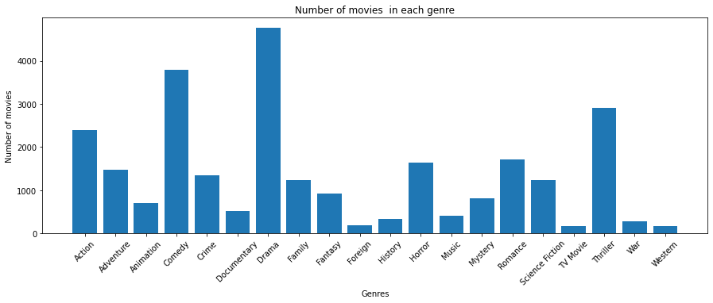

```python
ans = df_q1.groupby('genres').count()['id']
plt.subplots(figsize=(15,5))
plt.bar(height = ans.values,x = np.arange(ans.size));
plt.xticks(np.arange(ans.size), ans.index, rotation=45)
plt.xlabel('Genres');
plt.ylabel('Number of movies')
plt.title('Number of movies  in each genre')
```

The number of Drama, Comedy, Thriller, and Action movies are a lot more than the other genres

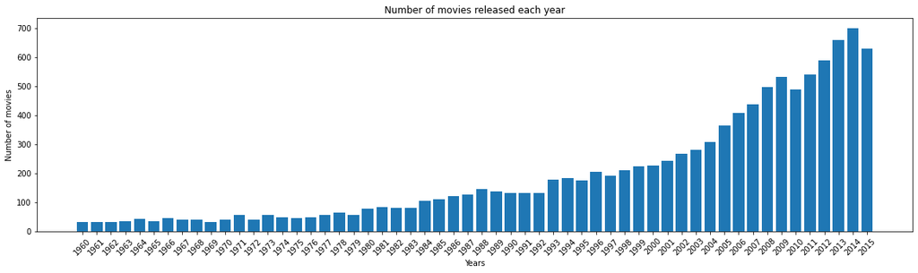

```python
ans = df.groupby('release_year').count()['id']
plt.subplots(figsize=(20,5))
plt.bar(height = ans.values,x = np.arange(ans.size));
plt.xticks(np.arange(ans.size), ans.index, rotation=45)
plt.xlabel('Years');
plt.ylabel('Number of movies')
plt.title('Number of movies released each year')
```

```python
df_q11=df[df.cast.notna()]
df_q11.reset_index(drop=True, inplace=True)
to_add = []
to_remove = []
for x in range(df_q11['cast'].size):
    if "|" in df_q11['cast'][x]:
        genlst = df_q11['cast'][x].split("|")
        to_remove.append(x)
        row = df_q11.iloc[x, :].copy()
        for gen in genlst:
            temp = row.copy()
            temp['cast'] = gen
            to_add.append(temp.values)

df_q11.drop(to_remove, inplace=True)
to_add = pd.DataFrame(to_add, columns = df.columns)
df_q11 = df_q11.append(to_add)
```

[figure not shown]

```python
ans = df_q11.groupby('cast').count()['id'].sort_values().reset_index()
ans = ans.query('id >= 43')
plt.subplots(figsize=(18,5))
plt.bar(height = ans['id'],x = ans['cast'])
plt.xticks(np.arange(ans['cast'].size), ans['cast'], rotation=45)
plt.xlabel('Years');
plt.ylabel('Actors')
plt.title('The actors that released the most number of movies')
```

Robert De Niro, Samuel L Jackson, Bruse Willis, and Nicolas Cage took part in the most movies

### Q2) Which production company made the most popular movies in each year?

splitting the production companies into separate rows and then removing the original rows.

```python
df.head()
df_q2 = df[df.production_companies.notna()]
df_q2.reset_index(drop=True, inplace=True)
to_add = []
to_remove = []
for x in range(df_q2['production_companies'].size):
    if "|" in df_q2['production_companies'][x]:
        prolst = df_q2['production_companies'][x].split("|")
        to_remove.append(x)
        row = df_q2.iloc[x, :].copy()
        for movie in prolst:
            temp = row.copy()
            temp['production_companies'] = movie
            to_add.append(temp.values)

df_q2.drop(to_remove, inplace=True)
to_add = pd.DataFrame(to_add, columns = df.columns)
df_q2 = df_q2.append(to_add)
df_q2.head()
```

|  | id | imdb_id | popularity | budget | revenue | original_title | cast | homepage | director | tagline | ... | overview | runtime | genres | production_companies | release_date | vote_count | vote_average | release_year | budget_adj | revenue_adj |
| --- | --- | --- | --- | --- | --- | --- | --- | --- | --- | --- | --- | --- | --- | --- | --- | --- | --- | --- | --- | --- | --- |
| 17 | 102899 | tt0478970 | 5.573184 | 130000000 | 518602163 | Ant-Man | Paul Rudd\|Michael Douglas\|Evangeline Lilly\|Cor... | http://marvel.com/movies/movie/180/ant-man | Peyton Reed | Heroes Don't Get Any Bigger | ... | Armed with the astonishing ability to shrink i... | 115 | Science Fiction\|Action\|Adventure | Marvel Studios | 7/14/15 | 3779 | 7.0 | 2015 | 1.195999e+08 | 4.771138e+08 |
| 47 | 286565 | tt3622592 | 2.968254 | 12000000 | 85512300 | Paper Towns | Nat Wolff\|Cara Delevingne\|Halston Sage\|Justice... | NaN | Jake Schreier | Get Lost. Get Found. | ... | Quentin Jacobsen has spent a lifetime loving t... | 109 | Drama\|Mystery\|Romance | Fox 2000 Pictures | 7/9/15 | 1252 | 6.2 | 2015 | 1.104000e+07 | 7.867128e+07 |
| 72 | 284289 | tt2911668 | 2.272044 | 0 | 45895 | Beyond the Reach | Michael Douglas\|Jeremy Irvine\|Hanna Mangan Law... | NaN | Jean-Baptiste Léonetti | NaN | ... | A high-rolling corporate shark and his impover... | 95 | Thriller | Furthur Films | 4/17/15 | 81 | 5.5 | 2015 | 0.000000e+00 | 4.222338e+04 |
| 74 | 347096 | tt3478232 | 2.165433 | 0 | 0 | Mythica: The Darkspore | Melanie Stone\|Kevin Sorbo\|Adam Johnson\|Jake St... | http://www.mythicamovie.com/#!blank/wufvh | Anne K. Black | NaN | ... | When Teela’s sister is murdered and a powerf... | 108 | Action\|Adventure\|Fantasy | Arrowstorm Entertainment | 6/24/15 | 27 | 5.1 | 2015 | 0.000000e+00 | 0.000000e+00 |
| 75 | 308369 | tt2582496 | 2.141506 | 0 | 0 | Me and Earl and the Dying Girl | Thomas Mann\|RJ Cyler\|Olivia Cooke\|Connie Britt... | http://www.foxsearchlight.com/meandearlandthed... | Alfonso Gomez-Rejon | A Little Friendship Never Killed Anyone. | ... | Greg is coasting through senior year of high s... | 105 | Comedy\|Drama | Indian Paintbrush | 6/12/15 | 569 | 7.7 | 2015 | 0.000000e+00 | 0.000000e+00 |

5 rows × 21 columns

Filtering the data and getting the most popular production company of each year

```python
p1 = df_q2.groupby(['release_year','production_companies'])['popularity'].sum()
p2 = p1.groupby('release_year').idxmax()
ans = pd.DataFrame([x[1]for x in p2.values], index = p2.index)
ans.transpose()
```

| release_year | 1960 | 1961 | 1962 | 1963 | 1964 | 1965 | 1966 | 1967 | 1968 | 1969 | ... | 2006 | 2007 | 2008 | 2009 | 2010 | 2011 | 2012 | 2013 | 2014 | 2015 |
| --- | --- | --- | --- | --- | --- | --- | --- | --- | --- | --- | --- | --- | --- | --- | --- | --- | --- | --- | --- | --- | --- |
| 0 | Shamley Productions | Walt Disney Productions | Metro-Goldwyn-Mayer (MGM) | Metro-Goldwyn-Mayer (MGM) | Metro-Goldwyn-Mayer (MGM) | Metro-Goldwyn-Mayer (MGM) | MGM Television | Embassy Pictures Corporation | Metro-Goldwyn-Mayer (MGM) | Danjaq | ... | Universal Pictures | Warner Bros. | Relativity Media | Warner Bros. | Warner Bros. | Warner Bros. | Columbia Pictures | Warner Bros. | Warner Bros. | Dentsu |

1 rows × 56 columns

Representing the most popular production companies of all time in a pie chart

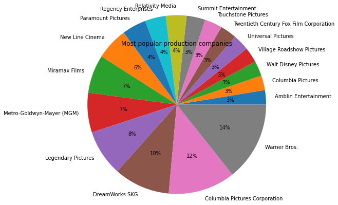

```python
p = df_q2.groupby('production_companies').sum()['popularity'].sort_values().reset_index()
ans = pd.DataFrame(p)
ans = ans.query('popularity >= 100')
l = [x[0] for x in ans.value_counts().index.values]
plt.pie(ans['popularity'], labels = l, radius=2, autopct='%1.0f%%')
plt.title('Most popular production companies')
```

### Q3) Who are the most popular directors

#### Most popular director each year

splitting the directors into separate rows and then removing the original rows.

```python
df.head()
df_q3 = df[df.director.notna()]
df_q3.reset_index(drop=True, inplace=True)
to_add = []
to_remove = []
for x in range(df_q3['director'].size):
    if "|" in df_q3['director'][x]:
        prolst = df_q3['director'][x].split("|")
        to_remove.append(x)
        row = df_q3.iloc[x, :].copy()
        for movie in prolst:
            temp = row.copy()
            temp['director'] = movie
            to_add.append(temp.values)

df_q3.drop(to_remove, inplace=True)
to_add = pd.DataFrame(to_add, columns = df.columns)
df_q3 = df_q3.append(to_add)
df_q3.head()
```

|  | id | imdb_id | popularity | budget | revenue | original_title | cast | homepage | director | tagline | ... | overview | runtime | genres | production_companies | release_date | vote_count | vote_average | release_year | budget_adj | revenue_adj |
| --- | --- | --- | --- | --- | --- | --- | --- | --- | --- | --- | --- | --- | --- | --- | --- | --- | --- | --- | --- | --- | --- |
| 0 | 135397 | tt0369610 | 32.985763 | 150000000 | 1513528810 | Jurassic World | Chris Pratt\|Bryce Dallas Howard\|Irrfan Khan\|Vi... | http://www.jurassicworld.com/ | Colin Trevorrow | The park is open. | ... | Twenty-two years after the events of Jurassic ... | 124 | Action\|Adventure\|Science Fiction\|Thriller | Universal Studios\|Amblin Entertainment\|Legenda... | 6/9/15 | 5562 | 6.5 | 2015 | 1.379999e+08 | 1.392446e+09 |
| 1 | 76341 | tt1392190 | 28.419936 | 150000000 | 378436354 | Mad Max: Fury Road | Tom Hardy\|Charlize Theron\|Hugh Keays-Byrne\|Nic... | http://www.madmaxmovie.com/ | George Miller | What a Lovely Day. | ... | An apocalyptic story set in the furthest reach... | 120 | Action\|Adventure\|Science Fiction\|Thriller | Village Roadshow Pictures\|Kennedy Miller Produ... | 5/13/15 | 6185 | 7.1 | 2015 | 1.379999e+08 | 3.481613e+08 |
| 2 | 262500 | tt2908446 | 13.112507 | 110000000 | 295238201 | Insurgent | Shailene Woodley\|Theo James\|Kate Winslet\|Ansel... | http://www.thedivergentseries.movie/#insurgent | Robert Schwentke | One Choice Can Destroy You | ... | Beatrice Prior must confront her inner demons ... | 119 | Adventure\|Science Fiction\|Thriller | Summit Entertainment\|Mandeville Films\|Red Wago... | 3/18/15 | 2480 | 6.3 | 2015 | 1.012000e+08 | 2.716190e+08 |
| 3 | 140607 | tt2488496 | 11.173104 | 200000000 | 2068178225 | Star Wars: The Force Awakens | Harrison Ford\|Mark Hamill\|Carrie Fisher\|Adam D... | http://www.starwars.com/films/star-wars-episod... | J.J. Abrams | Every generation has a story. | ... | Thirty years after defeating the Galactic Empi... | 136 | Action\|Adventure\|Science Fiction\|Fantasy | Lucasfilm\|Truenorth Productions\|Bad Robot | 12/15/15 | 5292 | 7.5 | 2015 | 1.839999e+08 | 1.902723e+09 |
| 4 | 168259 | tt2820852 | 9.335014 | 190000000 | 1506249360 | Furious 7 | Vin Diesel\|Paul Walker\|Jason Statham\|Michelle ... | http://www.furious7.com/ | James Wan | Vengeance Hits Home | ... | Deckard Shaw seeks revenge against Dominic Tor... | 137 | Action\|Crime\|Thriller | Universal Pictures\|Original Film\|Media Rights ... | 4/1/15 | 2947 | 7.3 | 2015 | 1.747999e+08 | 1.385749e+09 |

5 rows × 21 columns

Filtering the data and getting the most popular director of of each year.

```python
p1 = df_q3.groupby(['release_year','director'])['popularity'].sum()
p2 = p1.groupby('release_year').idxmax()
ans = pd.DataFrame([x[1]for x in p2.values], index = p2.index)
ans.transpose()
```

| release_year | 1960 | 1961 | 1962 | 1963 | 1964 | 1965 | 1966 | 1967 | 1968 | 1969 | ... | 2006 | 2007 | 2008 | 2009 | 2010 | 2011 | 2012 | 2013 | 2014 | 2015 |
| --- | --- | --- | --- | --- | --- | --- | --- | --- | --- | --- | --- | --- | --- | --- | --- | --- | --- | --- | --- | --- | --- |
| 0 | Alfred Hitchcock | Clyde Geronimi | Terence Young | Terence Young | Guy Hamilton | Terence Young | Ben Washam | Wolfgang Reitherman | Stanley Kubrick | Peter R. Hunt | ... | Len Wiseman | Gore Verbinski | Christopher Nolan | James Cameron | Christopher Nolan | Juno John Lee | Joss Whedon | Chris Buck | Christopher Nolan | Colin Trevorrow |

1 rows × 56 columns

Representing the most popular directors of all time in a pia chart.

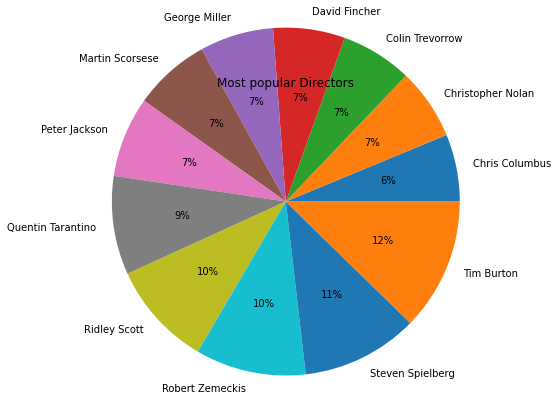

```python
p = df_q3.groupby('director').sum()['popularity'].sort_values().reset_index()
ans = pd.DataFrame(p)
ans = ans.query('popularity >= 30')
l = [x[0] for x in ans.value_counts().index.values]
plt.pie(ans['popularity'], labels = l, radius=2, autopct='%1.0f%%')
plt.title('Most popular Directors')
```

### Q4)what are the properties of popular Movies

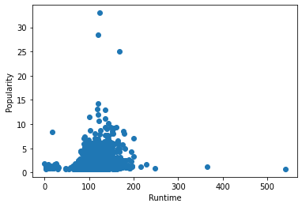

```python
tope = df.popularity.describe()[-2]
df_q4 = df.query('popularity >= @tope')
plt.scatter(df_q4['runtime'],df_q4['popularity'])
plt.ylabel('Popularity')
plt.xlabel('Runtime')
```

The data is almost symmetric and that means that the closer the runtime is to 125 mins the more popular.

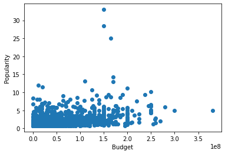

```python
plt.scatter(df_q4['budget'],df_q4['popularity'])
plt.ylabel('Popularity')
plt.xlabel('Budget')
```

The data shows that the buget doesn't have a relation with the popularity.

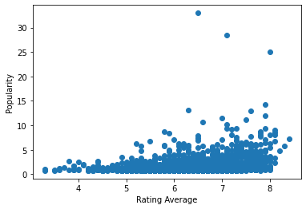

```python
plt.scatter(df_q4['vote_average'],df_q4['popularity'])
plt.ylabel('Popularity')
plt.xlabel('Rating Average')
```

## Conclusions

1) Adventure, Fantasy, Animation, Science Fiction, and Action are the most successful genres of all time.

2) Action movies get high revenues while getting a relatively low rating.

3) Documentary movies get very high ratings while being relatively unpopular.

4) Warner Bros, Columbia Pictures Corporation, DreamWorks SKG

### Limitations

data not containing writers and movie languages.

## Submitting your Project

> **Tip**: Before you submit your project, you need to create a .html or .pdf version of this notebook in the workspace here. To do that, run the code cell below. If it worked correctly, you should get a return code of 0, and you should see the generated .html file in the workspace directory (click on the orange Jupyter icon in the upper left).

> **Tip**: Alternatively, you can download this report as .html via the **File** > **Download as** submenu, and then manually upload it into the workspace directory by clicking on the orange Jupyter icon in the upper left, then using the Upload button.

> **Tip**: Once you've done this, you can submit your project by clicking on the "Submit Project" button in the lower right here. This will create and submit a zip file with this .ipynb doc and the .html or .pdf version you created. Congratulations!

```python
from subprocess import call
call(['python', '-m', 'nbconvert', 'Investigate_a_Dataset.ipynb'])
```

```
1
```